# Homework7

Sophie Kogut

2/26/2020

## Creating Fake Data Sets To Explore Hypotheses

Go back to your “thinking on paper” exercise, and decide on a pattern that you might expect in your experiment if a specific hypothesis were true. - If an ERV effects expression of the gene, we would expect a positive or negative linear regression line. If ERV is associated with ME/CFS, we would expect differential expression in cases vs.controls.

Using the methods we have covered in class, write code to create a random data set that has these attributes. Organize these data into a data frame or tibble with the appropriate structure.

Now write code to analyze the data (probably as an ANOVA or regression analysis, but possibly as a logistic regression or contingency table analysis. Write code to generate a useful graph of the data.

Try running your analysis multiple times to get a feeling for how variable the results are with the same parameters, but different sets of random numbers.

Now begin adjusting the means of the different groups. Given the sample sizes you have chosen, how small can the differences between the groups be (the “effect size”) for you to still detect a significant pattern (p < 0.05)?

Alternatively, for the effect sizes you originally hypothesized, what is the minimum sample size you would need in order to detect a statistically significant effect? Again, run the model a few times with the same parameter set to get a feeling for the effect of random variation in the data.

Write up your results in a markdown file, organized with headers and different code chunks to show your analysis. Be explicit in your explanation and justification for sample sizes, means, and variances.

If you have time, try repeating this exercise with one of the more sophisticated distributions, such as the gamma or negative binomial (depending on the kind of data you have). You will have to spend some time figuring out by trial and error the parameter values you will need to generate appropriate means and variances of the different groups.

# Simulating data for fatigue scores

```r
# Creating simulated dataframe for ERVs with a positive FC value
n_group <- 2 # number of treatment groups
n_name <- c("Cases", "Controls")
n_size <- c(35, 23)
n_mean <- c(7.3, 1.2)
n_sd<- c(2,1)
t_group <- rep(n_name, n_size)
t_group
```

```
##  [1] "Cases"    "Cases"    "Cases"    "Cases"    "Cases"    "Cases"
##  [7] "Cases"    "Cases"    "Cases"    "Cases"    "Cases"    "Cases"
## [13] "Cases"    "Cases"    "Cases"    "Cases"    "Cases"    "Cases"
## [19] "Cases"    "Cases"    "Cases"    "Cases"    "Cases"    "Cases"
## [25] "Cases"    "Cases"    "Cases"    "Cases"    "Cases"    "Cases"
## [31] "Cases"    "Cases"    "Cases"    "Cases"    "Cases"    "Controls"
## [37] "Controls" "Controls" "Controls" "Controls" "Controls" "Controls"
## [43] "Controls" "Controls" "Controls" "Controls" "Controls" "Controls"
## [49] "Controls" "Controls" "Controls" "Controls" "Controls" "Controls"
## [55] "Controls" "Controls" "Controls" "Controls"
```

```r
table(t_group)
```

```
## t_group
##    Cases Controls
##       35       23
```

```r
id <- 1:(sum(n_size))

res_var<- c(rnorm(n=n_size[1], mean= n_mean[1], sd=n_sd[1]),
            rnorm(n=n_size[2], mean= n_mean[2], sd=n_sd[2]))
ano_data<- data.frame(id, t_group, res_var)
str(ano_data)
```

```
## 'data.frame':    58 obs. of  3 variables:
##  $ id     : int  1 2 3 4 5 6 7 8 9 10 ...
##  $ t_group: Factor w/ 2 levels "Cases","Controls": 1 1 1 1 1 1 1 1 1 1 ...
##  $ res_var: num  8.12 7.52 4.02 6.91 8.68 ...
```

```r
ano_model<- aov(res_var~t_group, data=ano_data)
print(ano_model)
```

```
## Call:
##    aov(formula = res_var ~ t_group, data = ano_data)
##
## Terms:
##                  t_group Residuals
## Sum of Squares  627.0473  130.6006
## Deg. of Freedom        1        56
##
## Residual standard error: 1.527139
## Estimated effects may be unbalanced
```

```r
print(summary(ano_model))
```

```
##             Df Sum Sq Mean Sq F value Pr(>F)
## t_group      1  627.0   627.0   268.9 <2e-16 ***
## Residuals   56  130.6     2.3
## ---
## Signif. codes:  0 '***' 0.001 '**' 0.01 '*' 0.05 '.' 0.1 ' ' 1
```

```r
z<- summary(ano_model)
aggregate(res_var~t_group, data=ano_data, FUN=mean)
```

```
##    t_group  res_var
## 1    Cases 7.782646
## 2 Controls 1.061146
```

```r
unlist(z)
```

```
##          Df1          Df2      Sum Sq1      Sum Sq2     Mean Sq1     Mean Sq2
## 1.000000e+00 5.600000e+01 6.270473e+02 1.306006e+02 6.270473e+02 2.332153e+00
##     F value1     F value2      Pr(>F)1      Pr(>F)2
## 2.688706e+02           NA 4.862048e-23           NA
```

```r
ano_sum<- list(Fval= unlist(z)[7],
               probF= unlist(z)[9])
```

## ggplot for ANOVA of fatigue scores

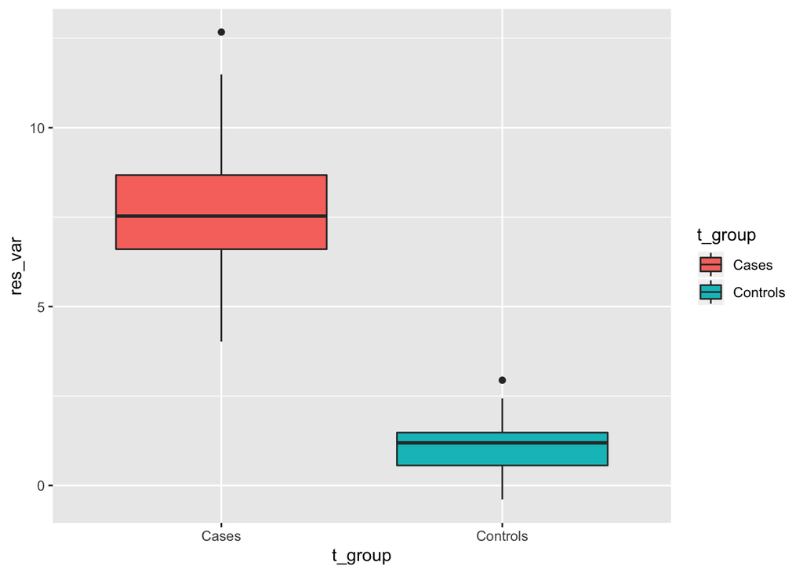

```r
library(ggplot2)
ano_plot <- ggplot(data=ano_data,
                   aes(x= t_group,
                       y= res_var,
                       fill= t_group)) +
                        geom_boxplot()
   # fill specifies grouping variables
print(ano_plot)
```

## Running the code without changing parameters

#### Run 1 Results:

```
        Df Sum Sq Mean Sq F value Pr(>F)
```

t_group 1 505.9 505.9 166.8 <2e-16 *** Residuals 56 169.9 3.0

#### Run 2 Results:

```
        Df Sum Sq Mean Sq F value Pr(>F)
```

t_group 1 540.5 540.5 168.7 <2e-16 *** Residuals 56 179.4 3.2

#### Run 3 Results:

```
       Df Sum Sq Mean Sq F value Pr(>F)
```

t_group 1 498.1 498.1 182 <2e-16 *** Residuals 56 153.3 2.7

Results are fairly consistent; the high F values indicate significant differences between the two groups.

## Adjusting the mean

What is the minimum difference between the groups that still yields a significant value?

```r
n_group <- 2 # number of treatment groups
n_name <- c("Cases", "Controls")
n_size <- c(35, 23)
n_mean <- c(5, 4)
n_sd<- c(2,1)
t_group <- rep(n_name, n_size)
t_group
```

```
##  [1] "Cases"    "Cases"    "Cases"    "Cases"    "Cases"    "Cases"
##  [7] "Cases"    "Cases"    "Cases"    "Cases"    "Cases"    "Cases"
## [13] "Cases"    "Cases"    "Cases"    "Cases"    "Cases"    "Cases"
## [19] "Cases"    "Cases"    "Cases"    "Cases"    "Cases"    "Cases"
## [25] "Cases"    "Cases"    "Cases"    "Cases"    "Cases"    "Cases"
## [31] "Cases"    "Cases"    "Cases"    "Cases"    "Cases"    "Controls"
## [37] "Controls" "Controls" "Controls" "Controls" "Controls" "Controls"
## [43] "Controls" "Controls" "Controls" "Controls" "Controls" "Controls"
## [49] "Controls" "Controls" "Controls" "Controls" "Controls" "Controls"
## [55] "Controls" "Controls" "Controls" "Controls"
```

```r
table(t_group)
```

```
## t_group
##    Cases Controls
##       35       23
```

```r
id <- 1:(sum(n_size))

res_var<- c(rnorm(n=n_size[1], mean= n_mean[1], sd=n_sd[1]),
            rnorm(n=n_size[2], mean= n_mean[2], sd=n_sd[2]))
ano_data<- data.frame(id, t_group, res_var)
str(ano_data)
```

```
## 'data.frame':    58 obs. of  3 variables:
##  $ id     : int  1 2 3 4 5 6 7 8 9 10 ...
##  $ t_group: Factor w/ 2 levels "Cases","Controls": 1 1 1 1 1 1 1 1 1 1 ...
##  $ res_var: num  4.66 1.93 7.26 3.32 3.35 ...
```

```r
ano_model<- aov(res_var~t_group, data=ano_data)
print(ano_model)
```

```
## Call:
##    aov(formula = res_var ~ t_group, data = ano_data)
##
## Terms:
##                   t_group Residuals
## Sum of Squares   13.23892 146.79304
## Deg. of Freedom         1        56
##
## Residual standard error: 1.619044
## Estimated effects may be unbalanced
```

```r
print(summary(ano_model))
```

```
##             Df Sum Sq Mean Sq F value Pr(>F)
## t_group      1  13.24  13.239   5.051 0.0286 *
## Residuals   56 146.79   2.621
## ---
## Signif. codes:  0 '***' 0.001 '**' 0.01 '*' 0.05 '.' 0.1 ' ' 1
```

```r
z<- summary(ano_model)
aggregate(res_var~t_group, data=ano_data, FUN=mean)
```

```
##    t_group  res_var
## 1    Cases 5.200240
## 2 Controls 4.223583
```

```r
unlist(z)
```

```
##          Df1          Df2      Sum Sq1      Sum Sq2     Mean Sq1     Mean Sq2
##   1.00000000  56.00000000  13.23891839 146.79303979  13.23891839   2.62130428
##     F value1     F value2      Pr(>F)1      Pr(>F)2
##   5.05050806           NA   0.02857693           NA
```

```r
ano_sum<- list(Fval= unlist(z)[7],
               probF= unlist(z)[9])
print(ano_sum)
```

```
## $Fval
## F value1
## 5.050508
##
## $probF
##    Pr(>F)1
## 0.02857693
```

## Running the code several times

#### Mean cases= 6, controls= 2

F value1 111.3013

Pr(>F)1 6.338663e-15 (significant)

#### Mean cases= 5, controls= 3

F value1 32.92059

Pr(>F)1 4.045124e-07 (significant)

#### Mean cases= 5, controls= 4

F value1 2.903942

Pr(>F)1 0.0939066 (loss of significance)

## Adjusting the sample sizes

```r
n_group <- 2 # number of treatment groups
n_name <- c("Cases", "Controls")
n_size <- c(2, 2)
n_mean <- c(7.3, 1.2)
n_sd<- c(2,1)
t_group <- rep(n_name, n_size)
t_group
```

```
## [1] "Cases"    "Cases"    "Controls" "Controls"
```

```r
table(t_group)
```

```
## t_group
##    Cases Controls
##        2        2
```

```r
id <- 1:(sum(n_size))

res_var<- c(rnorm(n=n_size[1], mean= n_mean[1], sd=n_sd[1]),
            rnorm(n=n_size[2], mean= n_mean[2], sd=n_sd[2]))
ano_data<- data.frame(id, t_group, res_var)
str(ano_data)
```

```
## 'data.frame':    4 obs. of  3 variables:
##  $ id     : int  1 2 3 4
##  $ t_group: Factor w/ 2 levels "Cases","Controls": 1 1 2 2
##  $ res_var: num  8.824 8.824 1.687 0.107
```

```r
ano_model<- aov(res_var~t_group, data=ano_data)
print(ano_model)
```

```
## Call:
##    aov(formula = res_var ~ t_group, data = ano_data)
##
## Terms:
##                  t_group Residuals
## Sum of Squares  62.83924   1.24808
## Deg. of Freedom        1         2
##
## Residual standard error: 0.7899635
## Estimated effects may be unbalanced
```

```r
print(summary(ano_model))
```

```
##             Df Sum Sq Mean Sq F value  Pr(>F)
## t_group      1  62.84   62.84   100.7 0.00979 **
## Residuals    2   1.25    0.62
## ---
## Signif. codes:  0 '***' 0.001 '**' 0.01 '*' 0.05 '.' 0.1 ' ' 1
```

```r
z<- summary(ano_model)
aggregate(res_var~t_group, data=ano_data, FUN=mean)
```

```
##    t_group   res_var
## 1    Cases 8.8241523
## 2 Controls 0.8970321
```

```r
unlist(z)
```

```
##          Df1          Df2      Sum Sq1      Sum Sq2     Mean Sq1     Mean Sq2
## 1.000000e+00 2.000000e+00 6.283924e+01 1.248085e+00 6.283924e+01 6.240423e-01
##     F value1     F value2      Pr(>F)1      Pr(>F)2
## 1.006971e+02           NA 9.785251e-03           NA
```

```r
ano_sum<- list(Fval= unlist(z)[7],
               probF= unlist(z)[9])
print(ano_sum)
```

```
## $Fval
## F value1
## 100.6971
##
## $probF
##     Pr(>F)1
## 0.009785251
```

## Running the code several times

#### Sample size: 29 cases, 29 controls. Even split using real total sample size.

F value1 277.2965

Pr(>F)1 2.367859e-23 (more significant than baseline)

#### Sample size: 5 cases, 6 controls. Mostly even split, with fewer samples.

F value1 47.72164

Pr(>F)1 7.003543e-05 (less significant than baseline)

#### Sample size: 2 cases, 2 controls. Even split, with very few samples.

F value1 35.24173

Pr(>F)1 0.02722212 (still significant, but less so)

#### Sample size: 0 cases, 3 controls. No cases, so nothing to compare.

F value1 33.5115

Pr(>F)1 0.004425407 (still significant with 0 cases, unsure how that is possible but it tells me to be skeptical of my p-values) I cannot find an adequate combination of sample size values that gives me insignificant results, which is bad.